# FIT5197 2018 S1 Assignment 2

## Task C: Sampling

C1. First write a sampling algorithm that uses the rejection method (for either one of the versions p(x|ë) above). In your report describe how this was designed. Define this in R, sample 1000 values and histogram them

```r
#function to obtain y-value
df_1 <- data.frame()
for(x in seq(from=0, to=2, by=0.01))
{
  lambda = 1.5
  px <- (lambda * exp (-(lambda) * x)) / (1 - exp (-(2) * lambda))

  df <- data.frame(px)
  df_1 <- rbind(df_1, df)
}

print(max(df_1))
```

```
## [1] 1.578594
```

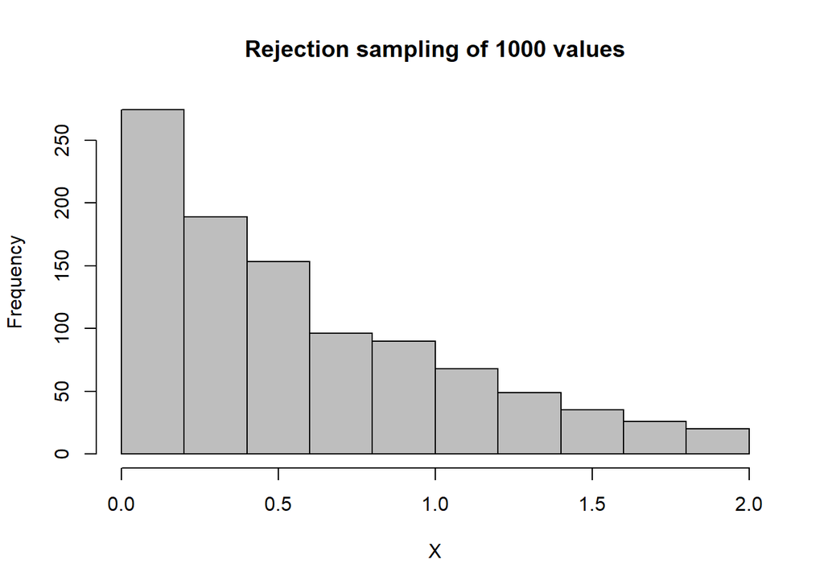

```r
#Lambda value given
lambda = 1.5

# Rejection sampling function
sample_function1 <- function ()
{
  repeat {
    x <- runif(1, 0, 2)
    y <- runif(1, 0, 1.578)
    px <- (lambda * exp (-(lambda) * x)) / (1 - exp (-(2) * lambda))
    if (y < px)
      return (x)
  }
}
#function for 1000 samples
sample_function2 <- function (n) {
  samples <- vector("numeric", n)
  for (i in 1:n) {
    samples[i] <- sample_function1()
  }
  return (samples)
}


rejection_sample <- sample_function2(1000)

#histogram for Rejection samples
hist (rejection_sample,
      main = "Rejection sampling of 1000 values",
      xlab = "X",
      col = "grey")
```

C.2: Second write a sampling algorithm that uses the inverse sampling method (for either one of the versions p(x|ë) above). In your report describe how this was designed. Define this in R, sample 1000 values and histogram them.

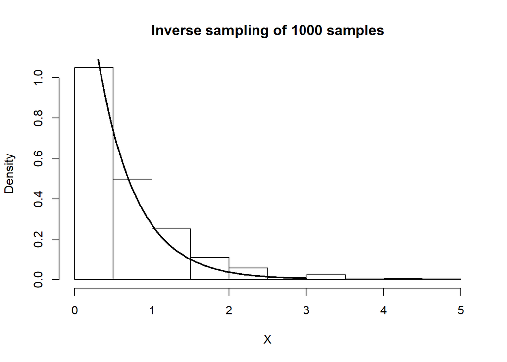

```r
#inverse CDF function
samples <- 1000
x <- runif(samples)
y <- -log(1-x)/lambda

#histogram plot for the inverse sampling function with curve.
hist(y, freq = F, xlab = "X", main = "Inverse sampling of 1000 samples")
curve(dexp(x, rate = 2),0, 3, lwd = 2, xlab = "", ylab = "", add = T)
```

```r
#creating empty vectors for each subclass
cloudy <- vector()
sprinkler <- vector()
rain <- vector()
wetgrass <- vector()

#
for (i in 1:1000) {
  r <- round(runif (4, 0, 1), 2)

  #condition for Cloud
  cloudy_values <- ifelse (r[1] <= 0.5, 0, 1)
  cloudy <- c(cloudy, cloudy_values)

  #join probability condition for Sprinklers
  sprinkler_values <- ifelse (r[1] <= 0.5, ifelse(r[2] <= 0.5, 0, 1), ifelse(r[2] <= 0.9, 0, 1))
  sprinkler <- c(sprinkler, sprinkler_values)

  #join probability condition for Rain
  rain_values <- ifelse (r[1] <= 0.5, ifelse(r[3] <= 0.8, 0, 1), ifelse(r[3] <= 0.2, 0, 1))
  rain <- c(rain, rain_values)

  #join probability condition for Wetgrass
  wetgrass_values <- ifelse (sprinkler_values == 0 & rain_values == 0, ifelse(r[4] <= 1, 0, 1),
                      ifelse (sprinkler_values == 1 & rain_values == 0, ifelse(r[4] <= 0.1, 0, 1),
                              ifelse (sprinkler_values == 0 & rain_values == 1, ifelse(r[4] <= 0.1, 0, 1),
                                      ifelse (sprinkler_values == 1 & rain_values == 1, ifelse(r[4] <= 0.01, 0, 1)))))
  wetgrass <- c(wetgrass, wetgrass_values)

}

samples <- cbind(cloudy, sprinkler, rain, wetgrass) #biniding all values together
total_samples <- samples[101:nrow(samples), ]  #ignoring first 100 samples

P_wetgrass_cloudy <- sum(samples[, "cloudy"] == 1 & samples[, "wetgrass"] == 1) / nrow(total_samples)
P_sprinkler_rain <- sum(samples[, "sprinkler"] == 1 & samples[, "rain"] == 1) / nrow(total_samples)

print(paste("Probability of wetgrass and cloudy is :",P_wetgrass_cloudy))
```

```
## [1] "Probability of wetgrass and cloudy is : 0.407777777777778"
```

```r
print(paste("Probability of Sprinkler and rain is :",P_sprinkler_rain))
```

```
## [1] "Probability of Sprinkler and rain is : 0.0788888888888889"
```